# Working with Vector Data, Part 1

Author

Roger Andre

Published

June 14, 2024

### Introducing the `sf` package

There are several R packages that provide support for working with spatial features, but in this class, we’re going to use `sf`. `sf` is short for “Simple Features”, which are described on Wikipedia as being…

> …a set of standards that specify a common storage and access model of geographic features made of mostly two-dimensional geometries (point, line, polygon, multi-point, multi-line, etc.) used by geographic databases and geographic information systems. It is formalized by both the Open Geospatial Consortium (OGC) and the International Organization for Standardization (ISO).

`sf` provides a standardized way to encode spatial vector data. It binds to ‘GDAL’ for reading and writing data, to ‘GEOS’ for geometrical operations, and to ‘PROJ’ for projection conversions and datum transformations.

Simple feature geometries

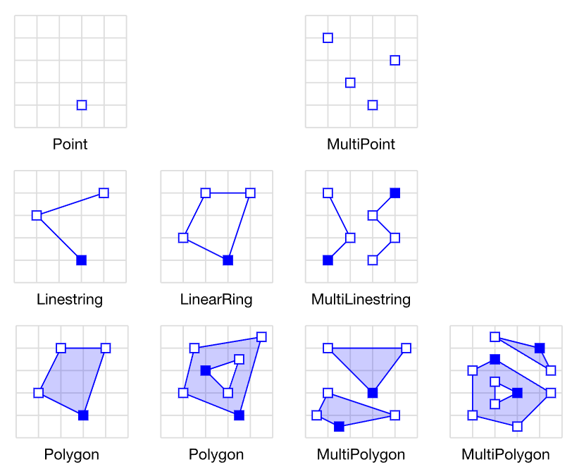

*Figure source: [Wikipedia GeoJSON primitives](https://en.wikipedia.org/wiki/GeoJSON)*

### Why use `sf`?

From a practical standpoint, `sf` is convenient because it represents features as a `data.frame` (or `tibble`) with an added geometry column. This is similar to how most databases implement spatial support, and in fact, the spatial operators in `sf` mostly match those found in systems like PostGIS and Snowflake (for example). This means that people who are already familiar with spatial operators like `st_buffer`, `st_intersect` etc. from other platforms will find `sf` fairly easy to understand. It also means that R users can treat spatial data like any other tabular data set and use tools from things like the Tidyverse.

*NOTE: Another extremely convenient feature of having features stored in dataframes is that they can be stored as a single RDS file.*

### Getting started with `sf`

A common workflow using `sf` might look like this:

#### **1. Open a spatial data set obtained from a public agency as a shapefile.**

*NOTE: This data was sourced from the [U.S. Census](https://www.census.gov/geographies/mapping-files/time-series/geo/cartographic-boundary.html) originally.*

```r
library(sf)
states <- st_read("../../data/intro_to_sf/cb_2018_us_state_20m.shp")
```

#### **2. Reproject the data into someting more suitable for spatial analysis**

```r
albers_states <- st_transform(states, crs = 5070)
head(albers_states, n=1)
```

```
Simple feature collection with 1 feature and 9 fields
Geometry type: MULTIPOLYGON
Dimension:     XY
Bounding box:  xmin: 1396621 ymin: 1838048 xmax: 1796585 ymax: 2037741
Projected CRS: NAD83 / Conus Albers
  STATEFP  STATENS    AFFGEOID GEOID STUSPS     NAME LSAD       ALAND
1      24 01714934 0400000US24    24     MD Maryland   00 25151100280
      AWATER                       geometry
1 6979966958 MULTIPOLYGON (((1722285 184...
```

#### **3. Obtain some spatial information about the data set**

Print the area of Washington State in sq km

```r
library(dplyr)
library(units)

albers_states |>
  filter(STUSPS == "WA") |>
  st_area() |>
  set_units(km^2)
```

```
178816.4 [km^2]
```

*Wikipedia says that the Area of Washington state is between 172,587 - 184,827 km2, depending on whether we measure just land area, or total area which includes water. Why the discrepancy?*

#### **4. View the data**

Make a simple plot with the geometry of Washington state.

Washington State, Albers projection

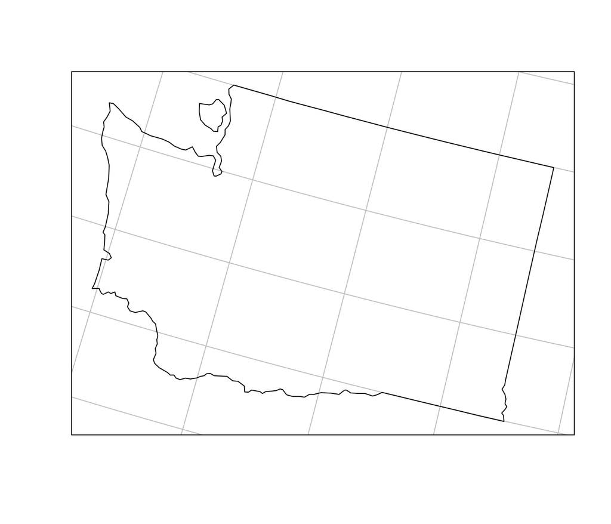

```r
albers_wa <- albers_states |>
  filter(STUSPS == "WA")

plot(albers_wa$geometry, graticule = TRUE)
```

Clearly, the scale of this data is pretty coarse, so it’s simplified out a fair amount of land area. (Something that’s good to remember when working with spatial data - spatial resolution matters! )

### **Practice 1. Open a shapefile in sf and create some simple plots**

**Your turn!** Using the same shapefile used above, `./../data/intro_to_sf/cb_2018_us_state_20m.shp`, create a couple sample plots visualizing states. See what happens when:

1. You change the CRS. (Try 5070, 4326 and 3857 EPSG codes)
2. You don’t specify `data$geometry` in the plot.
3. You select more than one state.

To help you get started, uncomment the code below and replace the `<blank>` values to make it work.

```r
# df <- st_<blank>("../Data/cb_2018_us_state_20m.shp", quiet = TRUE)
# lower_48 <- df |> <blank>(!STUSPS %in% c("AK", "HI", "PR"))
# lower_48 <- <blank>(lower_48, 5070)
# plot(lower_48$geometry)
```